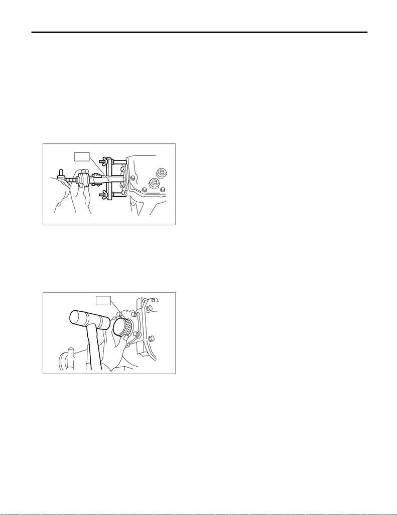

Rear Differential Side Oil Seal

DIFFERENTIALS

6. Rear Differential Side Oil Seal

A: INSPECTION

Check that there is no oil leakage from the side oil

seal. If there is any leakage, replace the oil seal.

B: REPLACEMENT

1) Remove the rear differential. <Ref. to DI-19, RE-

MOVAL, Rear Differential (T-type).>

2) Remove the rear differential side oil seal using a

ST or screwdriver wrapped with vinyl tape to pre-

vent the side retainer from scratching.

ST 398527700 PULLER ASSY

3) Using the ST, install the oil seal.

CAUTION:

Pay attention to the left and right of the oil seal.

NOTE:

• Use a new oil seal.

• Apply differential gear oil to the oil seal lips.

ST 398437700 DRIFT

4) Install the rear differential. <Ref. to DI-21, IN-

STALLATION, Rear Differential (T-type).>

ST

ST